# Mi primer R Markdown

El subtitulo

Tu nombre

2022-11-11

# Introducción

*R Markdown* permite combinar:

- texto formateado
- bloques de código R

De este modo, podemos elaborar informes un sólo lugar (archivo R Markdown) donde se edita tanto el texto del reporte, los códigos para construir los resultados a incluir, así como el formato general del documento y la gestión bibliográfica. Si el documento debe actualizarse (por ejemplo, cambian los datos), se efectúan en un sólo lugar todos los cambios y se re-compila el informe en el formato final deseado (PDF, Editor de Texto tipo Microsoft Word, diapositivas de presentación o un archivo dinámico tipo HTML).

## ¿Qué es un documento R Markdown?

Son simplemente ficheros de texto, PERO facilitan mucho la tarea de generar informes o transparencias con contenido estadístico, ya que permiten mezclar en un mismo documento texto y código R.

El código R (así como los resultados de la evaluación del código) se mostrarán automáticamente (gracias a `knitr`) en el documento final; de esta forma, se facilita mucho la realización de informes y transparencias ya que evita el tener que ir copiando los resultados (tablas, gráficos etc…) en el informe.

Los documentos *R Markdown* tienen 3 partes o elementos:

- encabezamiento o YAML header
- trozos de código R
- texto

## El encabezado

Se encuentra al principio del documento y está delimitado por el par de tres guiones (`---`)

```
---
title: "Mi primer R Markdown"
author: "Tu nombre"
date: "2022-11-11"
output: html_document
---
```

Este encabezado contiene los **metadatos** del documento, como su título, autor, fecha, además de una gran cantidad de opciones posibles que le permitirán configurar o personalizar todo el documento y su representación. Aquí, por ejemplo, la línea output: html_document indica que el documento de salida generado debe estar en formato HTML.

## Bloques de código

Como su nombre lo indica, contienen código R. Para que `{knitr}` distinga las instrucciones de R del texto normal tenemos que poner los bloques de código de R dentro de unas marcas o identificadores: `` ```{r} `` (donde r indica el nombre del lenguaje) al principio y `` ``` `` al final. Por ejemplo:

```r
mean(mtcars$mpg)
## [1] 20.09062
```

`{knitr}` interpreta este fragmento de texto como instrucciones de R porque van dentro de las marcas, y hará que R las ejecute y muestre los resultados en el documento final.

Los bloques de código se ejecutan y se muestra su resultado (a menos que indiquemos lo contrario), por ejemplo:

```r
mean(mtcars$mpg)
## [1] 20.09062
```

Los *chunks* pueden incluir diversas opciones que permiten una mayor flexibilidad en como se muestra el código y los resultados en el documento final. Las opciones más usadas son:

- `echo`
- `eval`
- `include`

También puede ser útil considerar las opciones:

- `message`
- `warning`

Para ver la lista completa puedes acceder [aquí](https://yihui.org/knitr/options/)

```r
mean(mtcars$mpg)
## [1] 20.09062
```

### Código en línea

Los resultados del código se pueden insertar directamente en el texto de un archivo `.Rmd` encerrando el código con `` `r ` ``.

Por ejemplo:

El cubo de dos es 8, o lo que es lo mismo, 2<sup>3</sup> = 8.

También podemos utilizar resultados de un bloque de código:

La muestra es de tamaño 32, su media es 20.090625, y su desviación estándar es 6.0269481.

En estos casos conviene utilizar también la función de redondeo:

La muestra es de tamaño 32, su media es 20.09, y su desviación estándar es 6.03.

## Gráficos

También podemos incluir gráficos:

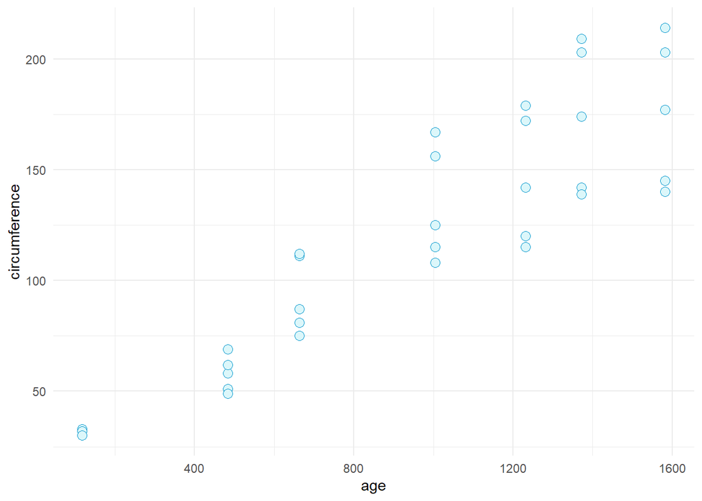

```r
ajuste <- lm(circumference ~ age, data = Orange)
coef <- coefficients(ajuste)

ggplot(data = Orange) +
  geom_point(mapping = aes(x = age, y = circumference), pch = 21, color = "#0098CD", fill = "#DCF7FA", size = 3) +
  theme_minimal()
```

o incluir imágenes (desde la web o desde nuestro ordenador)

```r
knitr::include_graphics('https://upload.wikimedia.org/wikipedia/commons/d/df/Logo_UNIR.png')
```

[output not shown]

## Formateo de texto

### Negritas, cursivas

Texto plano

*cursiva* y *cursiva*

**negrita** y **negrita**

*cursiva y negrita* o *cursiva y negrita* o *cursiva y negrita* o *cursiva y negrita*

### Superíndice y subíndice

superíndice<sup>2</sup> y subíndice<sub>2</sub>

### Tachado

Este texto está tachado, pero este no.

### Subrayado

Uso la etiqueta HTML para subrayar este texto y sigo sin subrayar.

### Color de fuente

Texto en rojo Texto en azul UNIR

### Párrafos

Los párrafos son una o múltiples líneas de texto adyacentes separadas por una o múltiples líneas en blanco.

Termina la línea con dos espacios para una nueva línea.  
Este texto comienzo en una nueva línea. Pero sin añadir los espacios en blanco al final, seguimos en la misma línea.

Este es un nuevo párrafo pues dejamos una línea en blanco.

Quiero separar este párrafo

de este, pero dejar **más** líneas en blanco no funciona.

Quiero separar este párrafo  
de este, lo logro con la etiqueta HTML.

O también usando

lo consigo.

### Citas en bloque

Para marcar un fragmento de texto como una cita en Markdown, puedes crear las llamadas citas en bloque, utilizando el signo de mayor que (>). Tienes dos opciones: marcar cada línea individual con este carácter o insertar únicamente uno al principio del párrafo de la cita sangrada y marcar el fin de la cita introduciendo una línea en blanco. La cita en bloque, a su vez, puede ser formateada con otros elementos.

> Esta es una **cita con *formato***. La cita continúa aquí.

> Este es otra **cita con *formato***.  
> Este fragmento continúa en la siguiente línea.  
> y sigo aqui

Esta línea ya no está sangrada.

# Título 1er nivel

## Título 2do nivel

### Título 3er nivel

#### Título 4to nivel

##### Título 5to nivel

###### Título 6to nivel

## Listas

- Primer ítem
- Segundo ítem
- Tercer ítem

o

- Primer ítem
- Segundo ítem
- Tercer ítem

o

- Primer ítem
- Segundo ítem
- Tercer ítem

Las listas ordenadas se logran con un número seguido de un punto.

1. Item uno
2. Item dos
3. Item tres

o

1. Item a
2. Item b
3. Item c

Aunque Markdown mostrará los items correctamente en orden, esto no es una buena idea:

1. Item uno
2. Item dos
3. Item tres

También puedes usar listas anidadas

1. Item uno
2. Item dos
3. Item tres
   - Sub-item
   - Sub-item
4. Item cuatro

o también

1. Item uno
2. Item dos
3. Item tres
   1. Sub-item
   2. Sub-item
4. Item cuatro

o también

- Item uno
- Item dos
- Item tres
  1. Sub-item
  2. Sub-item
- Item cuatro

## Notas al pie

Colocar notas en el pie de página[^1] es muy fácil[^2].

## Cometarios

En el documento compilado no se muestra las líneas comentadas.

## Tablas

```r
mtcars[1:7, 1:5]
##                    mpg cyl disp  hp drat
## Mazda RX4         21.0   6  160 110 3.90
## Mazda RX4 Wag     21.0   6  160 110 3.90
## Datsun 710        22.8   4  108  93 3.85
## Hornet 4 Drive    21.4   6  258 110 3.08
## Hornet Sportabout 18.7   8  360 175 3.15
## Valiant           18.1   6  225 105 2.76
## Duster 360        14.3   8  360 245 3.21
```

```r
knitr::kable(
  mtcars[1:7, 1:5],
  caption = "Un kable de knitr."
)
```

Un kable de knitr.

|  | mpg | cyl | disp | hp | drat |
| --- | --- | --- | --- | --- | --- |
| Mazda RX4 | 21.0 | 6 | 160 | 110 | 3.90 |
| Mazda RX4 Wag | 21.0 | 6 | 160 | 110 | 3.90 |
| Datsun 710 | 22.8 | 4 | 108 | 93 | 3.85 |
| Hornet 4 Drive | 21.4 | 6 | 258 | 110 | 3.08 |
| Hornet Sportabout | 18.7 | 8 | 360 | 175 | 3.15 |
| Valiant | 18.1 | 6 | 225 | 105 | 2.76 |
| Duster 360 | 14.3 | 8 | 360 | 245 | 3.21 |

Hay muchos otros paquetes de R que se pueden usar para generar tablas. Uno de ellos es `{flextable}`: si estás buscando un paquete de tablas que admita la más amplia gama de formatos de salida, `{flextable}` es probablemente una de las mejores opciones. Todos los formatos son compatibles con los formatos HTML, LaTeX y Office, y contienen las funciones de tabla más comunes (p. ej., formato condicional). Puede encontrar más información sobre flextable en [flextable](https://ardata-fr.github.io/flextable-book/)

```r
ftab <- flextable(mtcars[1:7,1:5])
ftab <- set_caption(ftab, caption = "Ejemplo 1")
ftab
```

Ejemplo 1

| mpg | cyl | disp | hp | drat |
| --- | --- | --- | --- | --- |
| 21.0 | 6 | 160 | 110 | 3.90 |
| 21.0 | 6 | 160 | 110 | 3.90 |
| 22.8 | 4 | 108 | 93 | 3.85 |
| 21.4 | 6 | 258 | 110 | 3.08 |
| 18.7 | 8 | 360 | 175 | 3.15 |
| 18.1 | 6 | 225 | 105 | 2.76 |
| 14.3 | 8 | 360 | 245 | 3.21 |

```r
flex_data <- flextable(mtcars[1:7,1:5]) %>%
  border_remove()%>%
  flextable::align(align = 'center', part = "all")

big_border <- fp_border(color = "#0098CD", width = 2)
std_border <- fp_border(color = "#0098CD", width = 1)

flex_data <- hline_top(flex_data,part="body", border = std_border)%>%
  vline(border = std_border, part = "body")%>%
  vline_left(border = std_border, part = "body")%>%
  hline_bottom(part="body", border = std_border)%>%
  fontsize(size = 11, part = "all")%>%
  bold(i=1,part='header')%>%
  bg(i =1,bg='#0098CD', part = "header")%>%
  color(i=1,color='white',part='header')%>%
  bg(i = c(1, 3, 5,7), j = seq(1,5,2), bg='#d5e7fb', part = "body")%>%
  font(fontname = "Calibri", part = "all")%>%
  width(j=2,width = 2)%>%
  width(j=1,width = 0.5)
flex_data <- fix_border_issues(flex_data)
flex_data
```

| mpg | cyl | disp | hp | drat |
| --- | --- | --- | --- | --- |
| 21.0 | 6 | 160 | 110 | 3.90 |
| 21.0 | 6 | 160 | 110 | 3.90 |
| 22.8 | 4 | 108 | 93 | 3.85 |
| 21.4 | 6 | 258 | 110 | 3.08 |
| 18.7 | 8 | 360 | 175 | 3.15 |
| 18.1 | 6 | 225 | 105 | 2.76 |
| 14.3 | 8 | 360 | 245 | 3.21 |

## Enlaces

https://www.unir.net

[UNIR](https://www.unir.net)

## Ecuaciones latex

[Aquí](https://en.wikibooks.org/wiki/LaTeX/Mathematics) encontrás una guía sobre cómo escribir distintas ecuaciones utilizando funcionalidades de $\LaTeX$.

$$A_{m,n} =
\begin{pmatrix}
a_{1,1} & a_{1,2} & \cdots & a_{1,n} \\
a_{2,1} & a_{2,2} & \cdots & a_{2,n} \\
\vdots & \vdots & \ddots & \vdots \\
a_{m,1} & a_{m,2} & \cdots & a_{m,n}
\end{pmatrix}$$

$$A_{m,n} =
\begin{bmatrix}
a_{1,1} & a_{1,2} & \cdots & a_{1,n} \\
a_{2,1} & a_{2,2} & \cdots & a_{2,n} \\
\vdots & \vdots & \ddots & \vdots \\
a_{m,1} & a_{m,2} & \cdots & a_{m,n}
\end{bmatrix}, \qquad
A_{m,n} =
\begin{Bmatrix}
a_{1,1} & a_{1,2} & \cdots & a_{1,n} \\
a_{2,1} & a_{2,2} & \cdots & a_{2,n} \\
\vdots & \vdots & \ddots & \vdots \\
a_{m,1} & a_{m,2} & \cdots & a_{m,n}
\end{Bmatrix}$$

$$A_{m,n} =
\begin{vmatrix}
a_{1,1} & a_{1,2} & \cdots & a_{1,n} \\
a_{2,1} & a_{2,2} & \cdots & a_{2,n} \\
\vdots & \vdots & \ddots & \vdots \\
a_{m,1} & a_{m,2} & \cdots & a_{m,n}
\end{vmatrix} ; \qquad
A_{m,n} =
\begin{Vmatrix}
a_{1,1} & a_{1,2} & \cdots & a_{1,n} \\
a_{2,1} & a_{2,2} & \cdots & a_{2,n} \\
\vdots & \vdots & \ddots & \vdots \\
a_{m,1} & a_{m,2} & \cdots & a_{m,n}
\end{Vmatrix}$$

$$|x| = \left\{
\begin{array}{ccl}
x & & \text{si } x\geq 0\\
-x & & \text{si } x< 0
\end{array}
\right.$$

[^1]: Aquí encuentras el texto de la nota al pie de página.
[^2]: **Las notas de pie de página** pueden *formatearse* también. Estas pueden ocupar varias líneas.